# Model evaluation and selection

# 1 Required packages

```r
library(parallel)
library(forecast)
library(tidyr)
library(dplyr)
library(ggplot2)
library(corrplot)
library(GA)
library(patchwork)
library(doRNG)
library(knitr)
library(glmmTMB)
```

# 2 Introduction

Considerations when choosing a “best” model:

- **We want a model that fits the observed data well**
- **We want a model that makes biological sense**
  - Includes plausible covariates, even if the precise mechanism is not known
- **We want a model that can make good predictions (in the future)**
  - Especially important in MSE context where forecasts are run
  - There may be special considerations when covariates extend beyond the observed range
- Metrics
  - Internal model metrics (AIC, LogLik)

# 3 Synthetic data creation

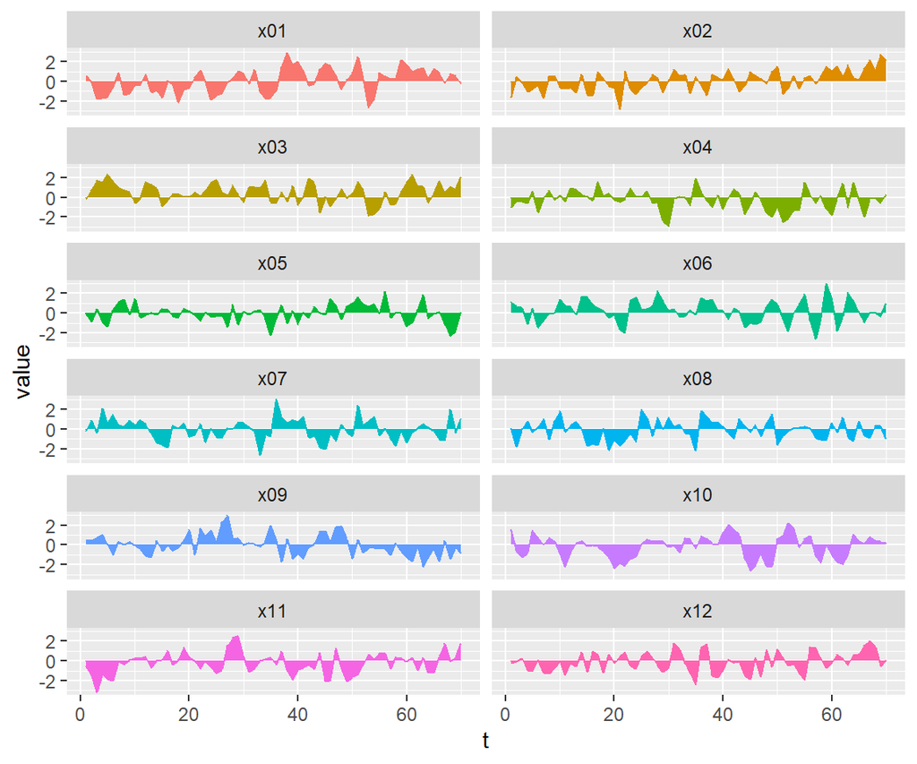

```r
set.seed(1235)
n <- 70
ncov <- 12
AR <- runif(ncov, min = 0, max = 0.9) # auto-regression coefficients
MA <- runif(ncov, min = 0.1, max = 0.5) # moving average coefficients
MA[sample(ncov, size = ncov*0.5)] <- 0 # set some MA to zero for AR1 process only

envvars <- paste0("x", formatC(x = seq(ncov), digits = 1, flag = 0))
tmp <- lapply(seq(ncov), FUN = function(i){
  # Generate the time series
  ts_data <- arima.sim(model = list(ar = AR[1], ma = MA[i]), n = n)
  return(ts_data)
})

tmp <- as.data.frame(matrix(unlist(tmp), nrow = n, ncol = ncov))
names(tmp) <- envvars
dat <- cbind(data.frame(t = seq(n)), tmp)

# add a trend to x01 and x02
dat$x01 <- dat$x01 + sd(dat$x01)*0.02*(dat$t-mean(dat$t)) # 2% of sd per year
dat$x02 <- dat$x02 + sd(dat$x02)*0.03*(dat$t-mean(dat$t)) # 3% of sd per year

# plot time series
df <- tidyr::pivot_longer(dat, cols = seq(ncol(dat))[-1])
ggplot(df) + aes(x = t, y = value, fill = name, color = name) +
  geom_area(show.legend = F) +
  facet_wrap(~ name, ncol = 2)
```

Generate ssb and rec

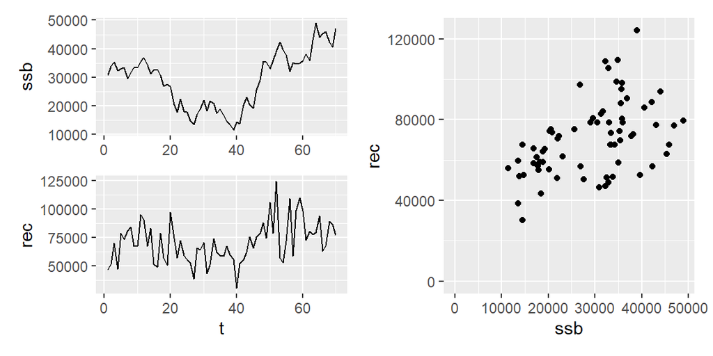

```r
# generate ssb (random walk)
set.seed(236)
dat$ssb <- 30000 - cumsum(rnorm(n, 0, 3000))

# generate recruitment (Ricker model + env mediation from x01 & x03)
dat$rec <- exp(log(5) + log(dat$ssb) - 2.5e-5*dat$ssb + 0.05*dat$x01 + 0.05*dat$x03)
dat$rec <- dat$rec * rlnorm(n, 0, 0.2) # additional random noise

p1 <- ggplot(dat) + aes(x = t, y = ssb) +
  geom_line()
p2 <- ggplot(dat) + aes(x = t, y = rec) +
  geom_line()
p3 <- ggplot(dat) + aes(x = ssb, y = rec) +
  geom_point() +
  lims(x = c(0, NA), y = c(0, NA))

layout <- "
AC
BC
"

p <- p1 + p2 + p3 + plot_layout(design = layout, axis_titles = "collect")
p
```

```r
# corrplot.mixed(cor(dat[,-1]))
```

# 4 Model definition

(Levi et al. 2003; Iles and Beverton 1998; Akimova et al. 2016; Iles 1994)

# 5 Standard metrics to select models

Concept of penalization (degrees of freedom)

ANOVA comparison (`summary`) - single term drops

```r
fmla <- formula(paste(c("rec ~ offset(log(ssb)) + ssb", envvars), collapse = " + "))
fmla
```

```
## rec ~ offset(log(ssb)) + ssb + x01 + x02 + x03 + x04 + x05 +
##     x06 + x07 + x08 + x09 + x10 + x11 + x12
```

```r
fit0 <- glm(fmla, data = dat, family = gaussian(link = "log"))
summary(fit0)
```

```
##
## Call:
## glm(formula = fmla, family = gaussian(link = "log"), data = dat)
##
## Coefficients:
##               Estimate Std. Error t value Pr(>|t|)
## (Intercept)  1.620e+00  1.113e-01  14.562  < 2e-16 ***
## ssb         -2.431e-05  3.449e-06  -7.048 2.88e-09 ***
## x01          6.331e-02  2.502e-02   2.530   0.0142 *
## x02          1.956e-02  2.808e-02   0.696   0.4891
## x03          3.920e-02  2.921e-02   1.342   0.1850
## x04          2.914e-03  2.663e-02   0.109   0.9133
## x05          3.671e-02  2.927e-02   1.254   0.2151
## x06         -2.556e-03  2.364e-02  -0.108   0.9143
## x07         -2.030e-02  2.691e-02  -0.755   0.4537
## x08          7.241e-03  2.861e-02   0.253   0.8011
## x09          2.793e-03  3.201e-02   0.087   0.9308
## x10          7.328e-03  2.423e-02   0.302   0.7634
## x11          1.059e-02  2.512e-02   0.422   0.6749
## x12         -2.222e-02  2.852e-02  -0.779   0.4393
## ---
## Signif. codes:  0 '***' 0.001 '**' 0.01 '*' 0.05 '.' 0.1 ' ' 1
##
## (Dispersion parameter for gaussian family taken to be 237875389)
##
##     Null deviance: 3.1339e+10  on 69  degrees of freedom
## Residual deviance: 1.3321e+10  on 56  degrees of freedom
## AIC: 1563.1
##
## Number of Fisher Scoring iterations: 6
```

## 5.1 Stepwise search with AIC

Let’s compare fit0 and fit with AIC and cross validation metrics

```r
# model with all original variables in fit0
all_variables <- "rec ~ ."
# Variables that should always be in the model (Ricker without env.)
fixed_variables <- "rec ~ offset(log(ssb)) + ssb"

fit <- step(fit0,
  scope = list(
    lower = as.formula(fixed_variables),
    upper = as.formula(all_variables)
  ),
  direction = "both",
  trace = FALSE # set to TRUE if you would like to see the model selections steps
)

summary(fit)
```

```
##
## Call:
## glm(formula = rec ~ ssb + x01 + offset(log(ssb)), family = gaussian(link = "log"),
##     data = dat)
##
## Coefficients:
##               Estimate Std. Error t value Pr(>|t|)
## (Intercept)  1.618e+00  8.878e-02  18.226  < 2e-16 ***
## ssb         -2.364e-05  2.703e-06  -8.744  1.1e-12 ***
## x01          6.795e-02  2.077e-02   3.271  0.00169 **
## ---
## Signif. codes:  0 '***' 0.001 '**' 0.01 '*' 0.05 '.' 0.1 ' ' 1
##
## (Dispersion parameter for gaussian family taken to be 213719452)
##
##     Null deviance: 3.1339e+10  on 69  degrees of freedom
## Residual deviance: 1.4319e+10  on 67  degrees of freedom
## AIC: 1546.2
##
## Number of Fisher Scoring iterations: 4
```

```r
c(fit0=AIC(fit0), fit=AIC(fit)) # comparison of AIC
```

```
##     fit0      fit
## 1563.139 1546.197
```

```r
# compare the AIC of 'true' model
# AIC(update(fit, formula("~ . + x03")))
```

Akaike rule-of-thumb for improved model: $\delta AIC \geq 2$

## 5.2 Visualizing marginal effects

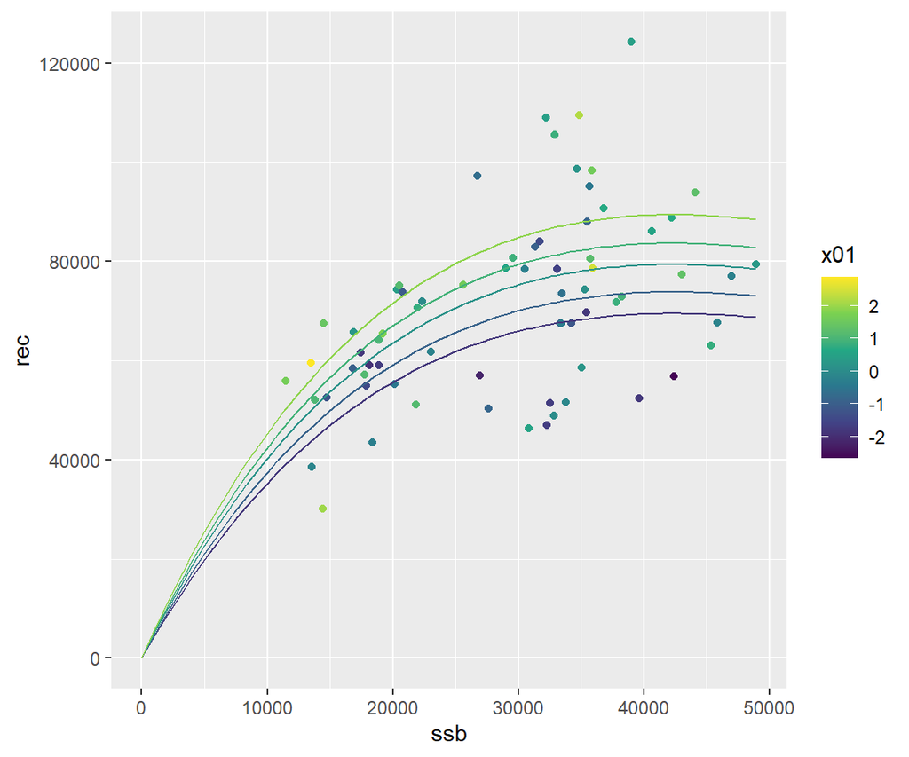

```r
envvarsKeep <- intersect(names(coef(fit)), envvars) # maintained env. covariates
# envvarsKeep <- c("x01", "x03")
focusVar <- envvarsKeep[1] # choose covariate of focus

## generate data for prediction
# focus covariate generated at 5 quantile levels, other env covariates use median
L <- lapply(envvarsKeep, FUN = function(x){
  if(x == focusVar){probs = c(0.05,0.25,0.5,0.75,0.95)}else{probs <- 0.5}
  quantile(dat[,x], probs = probs)
})
names(L) <- envvarsKeep
L[["ssb"]] <-  seq(0, max(dat$ssb), len = 100)

nd <- expand.grid(L)
nd$rec <- predict(fit, newdata = nd, type = "response")

ggplot(dat) + aes(x = ssb, y = rec, col = get(focusVar)) +
  geom_point() +
  scale_color_continuous(name = focusVar, type = "viridis") +
  geom_line(data = nd, mapping = aes(group = get(focusVar)))
```

# 6 Cross-validation

- Tests how well a model can predict unseen data (validation)
- Flexible metrics can be specified depending on the goals of the model

Cross validation is a very flexible framework that

- Flavours of splitting (random, block, holdout)
- Metrics for cost function (RMSE, MAE, MdAPE, …)

## 6.1 Metrics

More info on pros/cons of different metrics

```r
# Mean Squared Error (MSE)
mse <- function(y, yhat){
  mean((y - yhat)^2, na.rm = TRUE)
}

# Root Mean Squared Error (RMSE)
rmse <- function(y, yhat){
  sqrt(mean((y - yhat)^2, na.rm = TRUE))
}

# Mean Absolute Percentage Error (MAPE)
mape <- function(y, yhat){
  mean(abs(y - yhat) / y, na.rm = TRUE)
}

# Median Absolute Percentage Error (MAPE)
mdape <- function(y, yhat){
  median(abs(y - yhat) / y, na.rm = TRUE)
}

# Mean Absolute Error (MAE)
mae <- function(y, yhat){
  mean(abs(y - yhat), na.rm = TRUE)
}

# Mean Absolute Scaled Error (MASE)
mase <- function(y, yhat, yhat_naive){
  mean(abs(y - yhat), na.rm = TRUE) /
    mean(abs(y - yhat_naive), na.rm = TRUE)
}
```

## 6.2 Repeated k-fold

### 6.2.1 Functions

```r
# Determines k-fold partitions for a given number of samples
# n is the number of samples; k is the number of partitions
kfold <- function(n, k = NULL){
  if(is.null(k)){k <- n} # if undefined, assume leave-one-out (LOO) CV
  res <- vector(mode="list", k)
  n.remain <- seq(n)
  for(i in seq(k)){
    samp <- sample(seq(length(n.remain)), ceiling(length(n.remain)/(k-i+1)))
    res[[i]] <- n.remain[samp]
    n.remain <- n.remain[-samp]
  }
  return(res)
}

# perform repeated k-fold cross validation
# n and k are passed to kfold; seed is a integer value passed to set.seed
cvFun <- function(model = NULL, nperm = 10, k = 5, seed = 1){

  if(any(class(model) %in% "glmmTMB")){
    modelData <- model$frame
    y <- model.response(model$frame)
  }
  if(any(class(model) %in% "lm")){
    modelData <- model$data
    y <- model$y
  }
  res <- vector("list", nperm)
  set.seed(seed)
  for(j in seq(nperm)){ # for each permutation j
    ks <- kfold(n = nrow(modelData), k = k)
    res[[j]] <- data.frame(perm = j, k = NaN, y = y, yhat = NaN)
    for(i in seq(ks)){ # for each partition k
      train <- -ks[[i]]
      valid <- ks[[i]]
      fit.k <- update(object = model, data = modelData[train,]) # update model with training data
      res[[j]]$k[valid] <- i
      res[[j]]$yhat[valid] <- predict(object = fit.k, newdata = modelData[valid,], type = "response")
    }
  }
  res <- do.call("rbind", res)
  return(res)
}
```

### 6.2.2 k-fold partitioning

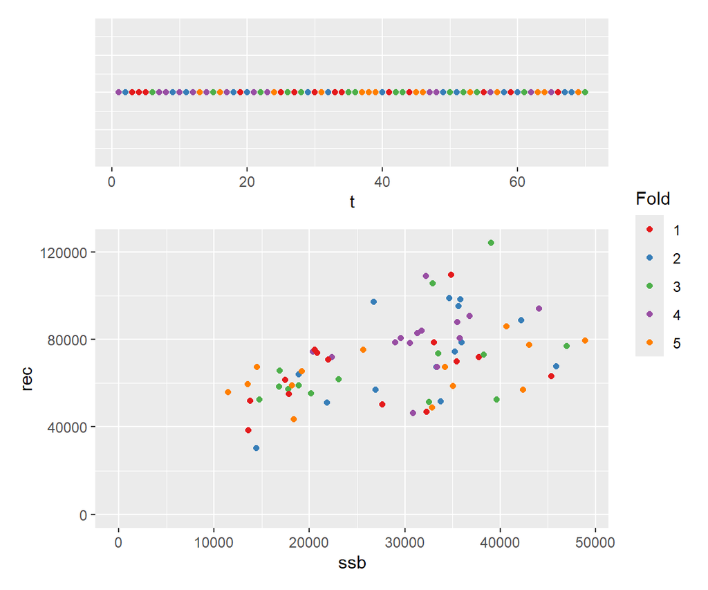

```r
ks <- kfold(n = nrow(dat), k = 5)
df <- as.data.frame(do.call("cbind", ks))
names(df) <- seq(ncol(df))

df <- pivot_longer(df, cols = 1:5)
df <- df[order(df$value),]

p1 <- ggplot(dat) + aes(x = t, y = 1, col = df$name) +
  geom_point() +
  scale_color_brewer(palette = "Set1", name = "Fold") +
  theme(axis.title.y = element_blank(), axis.text.y = element_blank(),
    axis.ticks.y = element_blank(), axis.line.y = element_blank())

p2 <- ggplot(dat) + aes(x = ssb, y = rec, col = df$name) +
  geom_point() +
  lims(x = c(0,NA), y = c(0,NA)) +
  scale_color_brewer(palette = "Set1", name = "Fold")

layout = "
AA
BB
BB
"

p <- p1 + p2 + plot_layout(design = layout, guides = "collect")
p
```

## 6.3 Model selection

You can compare models of different structure as well. For example, AIC may not be comparible between models of different structure, e.g. mixed models with random effects. Comparison should be made using same folds (e.g. use of random seed). A variety of metrics could be used for the final model selection.

```r
res0 <- cvFun(model = fit0, nperm = 5, k = 5, seed = 1111)
res <- cvFun(model = fit, nperm = 5, k = 5, seed = 1111)

# mixed model with autoregressive term on time (t)
fmlaMM <- formula(rec ~ ssb + offset(log(ssb)) + x01 + ar1(t + 0 | 1))
fitMM <- glmmTMB(fmlaMM, data = dat, family = gaussian(link = "log"))
resMM <- cvFun(model = fitMM, nperm = 5, k = 5, seed = 1111)


cvStats0 <- with(res0, c(
  mse = mse(y = y, yhat = yhat),
  rmse = rmse(y = y, yhat = yhat),
  mape = mape(y = y, yhat = yhat),
  mdape = mdape(y = y, yhat = yhat),
  mae = mae(y = y, yhat = yhat)
))

cvStats <- with(res, c(
  mse = mse(y = y, yhat = yhat),
  rmse = rmse(y = y, yhat = yhat),
  mape = mape(y = y, yhat = yhat),
  mdape = mdape(y = y, yhat = yhat),
  mae = mae(y = y, yhat = yhat)
))

cvStatsMM <- with(resMM, c(
  mse = mse(y = y, yhat = yhat),
  rmse = rmse(y = y, yhat = yhat),
  mape = mape(y = y, yhat = yhat),
  mdape = mdape(y = y, yhat = yhat),
  mae = mae(y = y, yhat = yhat)
))

tmp <- cbind(cvStats0, cvStats, cvStatsMM)
tmp <- as.data.frame(t(apply(tmp, 1, FUN = function(x){
  paste0(format(x, scientific = TRUE, digits = 3),
    ifelse(x == min(x, na.rm = T), "*", " "))
})))

names(tmp) <- c("res0", "res", "resMM")
tmp
```

|  | res0 | res | resMM |
| --- | --- | --- | --- |
| mse | 3.43e+08 | 2.20e+08* | 2.40e+08 |
| rmse | 1.85e+04 | 1.48e+04* | 1.55e+04 |
| mape | 2.12e-01 | 1.78e-01* | 1.87e-01 |
| mdape | 1.57e-01 | 1.31e-01* | 1.43e-01 |
| mae | 1.43e+04 | 1.15e+04* | 1.24e+04 |

In this case, the addition of the random intercept with an autoregressive structure based on time (t) did not improve the model for any of the evaluated metrics.

## 6.4 Covariate selection with machine learning

Number of model combinations is $combinations = 2^n-1$, and here we have n = 12 covariates and 4095 possible combinations.

### 6.4.1 Fitness function

```r
fitnessFun <- function(genes = NULL, data = NULL, nperm = 10, k = 5, ffSeed = 1, fitnessOnly = TRUE){

  fmlaGA <<- paste(c("rec ~ offset(log(ssb)) + ssb", envvars[as.logical(genes)]), collapse = " + ")
  fit <- glm(formula = fmlaGA, data = data, family = gaussian(link = "log"))

  res <- cvFun(model = fit, nperm = nperm, k = k, seed = ffSeed)

  fitness <- -1 * mape(y = res$y, yhat = res$yhat) # to maximize, so reverse sign

  if(!fitnessOnly){
    byPerm <- res %>% group_by(perm) %>% summarise(mape = mape(y = y, yhat = yhat))
  }

  if(fitnessOnly){
    out <- fitness
  }else{
    out <- list(fitness = fitness, byPerm = byPerm)
  }

  return(out)
}
```

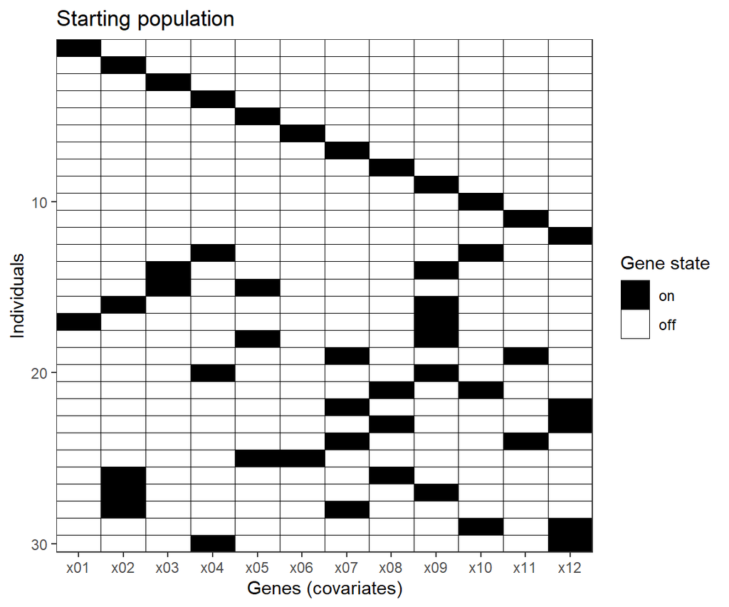

```r
popSize <- max(30, length(envvars)) # number of individuals

PARS <- seq(envvars)*0
startPop <- matrix(0, ncol = length(PARS), nrow = popSize)
diag(startPop[seq(PARS),]) <- 1
if(popSize > length(PARS)){
  hit <- seq(nrow(startPop))[-seq(PARS)]
  startPop[hit, ] <- t(apply(startPop[hit, ], 1,
    FUN = function(x){x[sample(seq(PARS), size = 2)] <- 1; x}))
}

tmp <- startPop
tmp[] <- c("off", "on")[c(tmp)+1]
df <- as.data.frame(tmp)
names(df) <- envvars
df$ind <- seq(nrow(df))

df_long <- df %>%
  pivot_longer(cols = -ind, names_to = "variable", values_to = "value")


ggplot(df_long, aes(x = variable, y = ind, fill = factor(value))) +
  geom_tile(colour = 1) +
  scale_fill_manual(name = "Gene state", values = c("black", "white"), breaks = c("on", "off")) +   # Use color scale (e.g., viridis)
  scale_y_reverse(expand = c(0, 0)) +
  scale_x_discrete(expand = c(0, 0)) +
  labs(x = "Genes (covariates)", y = "Individuals", title = "Starting population") +
  theme_bw()
```

Distribution of fitness for starting population

### 6.4.2 Check fitness of starting pop

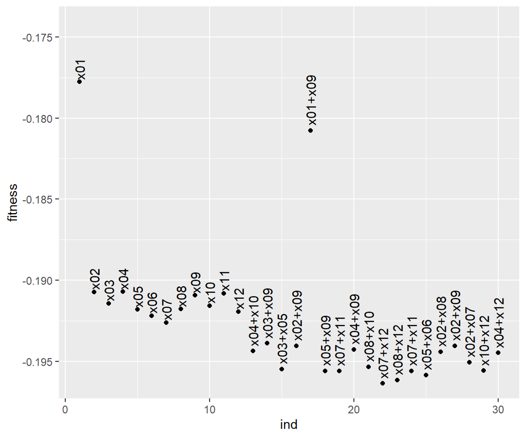

```r
tmp1 <- apply(startPop, 1, FUN = function(x){fitnessFun(x, data = dat)})
tmp2 <- apply(startPop, 1, FUN = function(x){paste(envvars[as.logical(x)], collapse = "+")})
tmp <- data.frame(ind = seq(tmp1), fitness = tmp1, covariates = tmp2)

ggplot(tmp) + aes(x = ind, y = fitness, label = covariates) +
  geom_point() +
  geom_text(angle = 90, hjust = -0.1, vjust = 0.5) +
  scale_y_continuous(expand = expansion(mult = c(0.05,0.25)))
```

The fitness of the model with “x01” alone is already a clear standout with highest fitness (lowest mape).

### 6.4.3 Genetic algorithm

Next, we will provide this starting population to a genetic algorithm (`GA::ga()`) of type “binary”, which will turn off/on the covariates, and test the resulting fitness. According to the [vignette of the GA package](https://cran.r-project.org/web/packages/GA/vignettes/GA.html):

> *Genetic algorithms (GAs) are stochastic search algorithms inspired by the basic principles of biological evolution and natural selection. GAs simulate the evolution of living organisms, where the fittest individuals dominate over the weaker ones, by mimicking the biological mechanisms of evolution, such as selection, crossover and mutation.*

Likewise, these aspects can be controlled by the `ga` function with secific arguments, e.g. the probability of gene crossover (`pcrossover`), the probability of mutation (`pmutation`), etc.

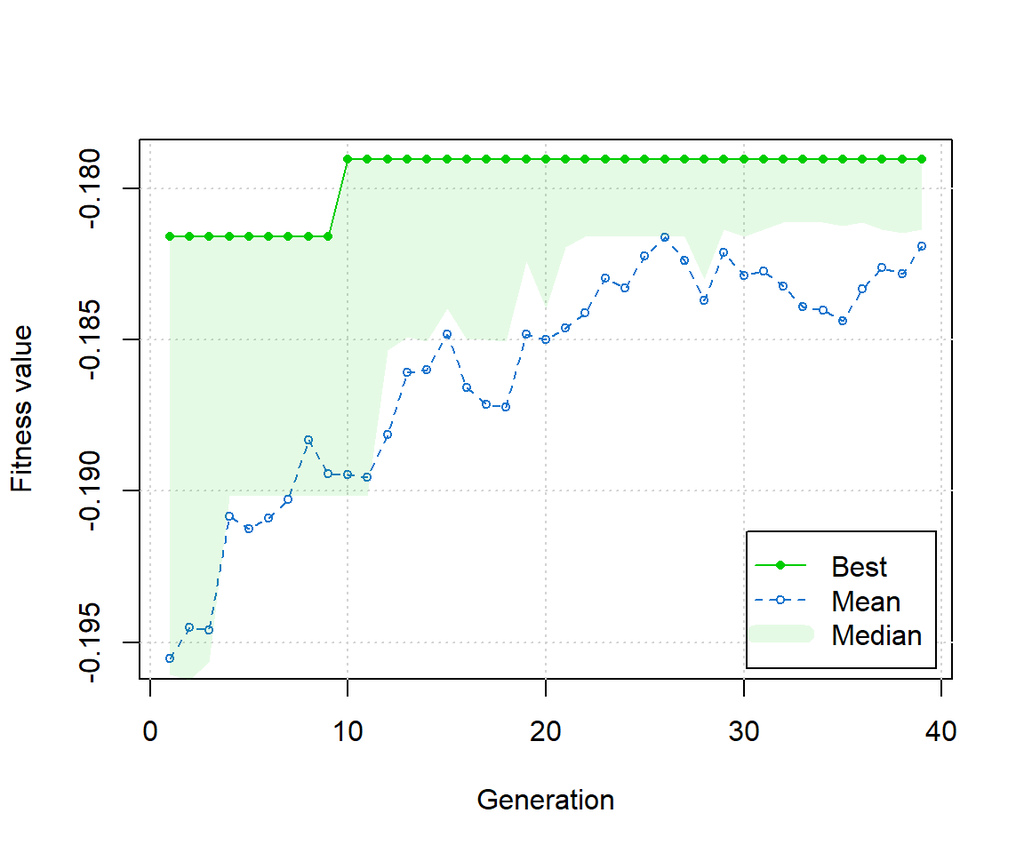

```r
# extra diagnostic data object to save all generations
postfit <- function(object, ...){
  pop <- as.data.frame(object@population)
  names(pop) <- paste0("par", seq(ncol(pop)))
  pop$fitness <- object@fitness
  pop$iter <- object@iter
  # update info
  if(!exists(".pop", envir = globalenv()))
    assign(".pop", NULL, envir = globalenv())
  .pop <- get(".pop", envir = globalenv())
  assign(".pop", rbind(.pop, pop), envir = globalenv())
  # output the input ga object (this is needed!)
  object
}

.pop <- NULL # make sure diagnostic output is empty
ga.fit <- ga(
  type = "binary", # for covariate selection
  fitness = fitnessFun, # fitness function
  nBits = length(envvars), # number of genes (covariates)
  suggestions = startPop, # starting population suggestions
  popSize = popSize, # population size
  pcrossover = 0.8, pmutation = 0.1, elitism = popSize*0.05, # default settings
  parallel = round(parallel::detectCores()/2), # parallel computing using half of available cores
  maxiter = 100, # max number of generations
  run = 30, # the max number of generations without any improvement
  monitor = FALSE, # set to TRUE to monitor fitness evolution
  data = dat, # input data
  seed = 1, # for reproducibility
  postFitness = postfit # extra diagnostics function
)

plot(ga.fit) # plot development
```

### 6.4.4 Pareto front

```r
.pop$nVar <- rowSums(.pop[,seq(envvars)])
.pop$fracVar <- .pop$nVar / length(envvars)
names(.pop)[seq(envvars)] <- envvars

# pareto front
agg <- aggregate(fitness ~ fracVar, data = .pop, FUN = max)

# determine standard error of pareto front models
parFront <- merge(x = agg, y = .pop, all.x = T)
parFront <- unique(parFront[,c(envvars, "nVar", "fracVar", "fitness")])
parFront <- parFront[order(parFront$nVar),]
parFront
```

|  | x01 | x02 | x03 | x04 | x05 | x06 | x07 | x08 | x09 | x10 | x11 | x12 | nVar | fracVar | fitness |
| --- | --- | --- | --- | --- | --- | --- | --- | --- | --- | --- | --- | --- | --- | --- | --- |
| 1 | 0 | 0 | 0 | 0 | 0 | 0 | 0 | 0 | 0 | 0 | 0 | 0 | 0 | 0.00000000 | -0.1901654 |
| 106 | 1 | 0 | 0 | 0 | 0 | 0 | 0 | 0 | 0 | 0 | 0 | 0 | 1 | 0.08333333 | -0.1815953 |
| 327 | 1 | 0 | 1 | 0 | 0 | 0 | 0 | 0 | 0 | 0 | 0 | 0 | 2 | 0.16666667 | -0.1790572 |
| 517 | 1 | 0 | 1 | 0 | 0 | 1 | 0 | 0 | 0 | 0 | 0 | 0 | 3 | 0.25000000 | -0.1800131 |
| 542 | 1 | 0 | 1 | 0 | 0 | 1 | 1 | 0 | 0 | 0 | 0 | 0 | 4 | 0.33333333 | -0.1824538 |
| 543 | 1 | 1 | 1 | 0 | 0 | 1 | 1 | 0 | 0 | 0 | 0 | 0 | 5 | 0.41666667 | -0.1850178 |
| 544 | 1 | 1 | 1 | 0 | 0 | 0 | 0 | 1 | 1 | 1 | 0 | 0 | 6 | 0.50000000 | -0.1953936 |

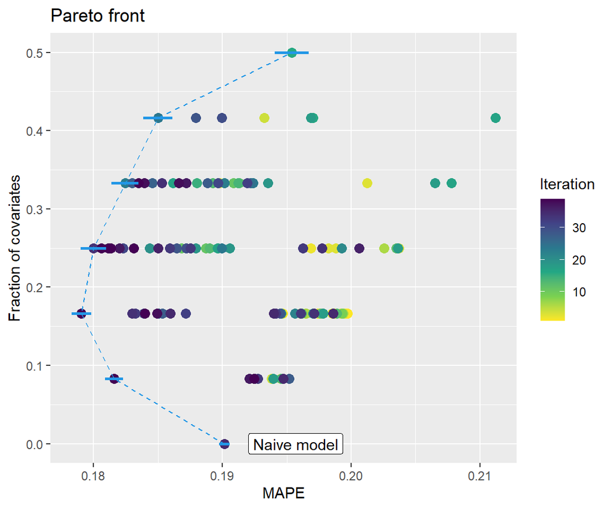

```r
parFront$se <- NaN
for(i in seq(nrow(parFront))){
  genes.i <- parFront[i,envvars]
  tmp <- fitnessFun(genes = genes.i, data = dat, nperm = 20, k = 5, ffSeed = 1, fitnessOnly = F)
  parFront$se[i] <- sd(tmp$byPerm$mape)/sqrt(nrow(tmp$byPerm))
}

parFront$best <- FALSE
hit <- max(which(parFront$fitness > c(-Inf, (parFront$fitness + parFront$se)[-nrow(parFront)])))
parFront$best[hit] <- TRUE

ggplot(.pop) + aes(x = -fitness, y = fracVar, color = iter) +
  geom_point(size = 3) +
  # scale_color_viridis_c(name = "Iteration", option = "magma", direction = -1) +
  scale_color_continuous(name = "Iteration", type = "viridis", direction = -1) +
  geom_path(data = parFront, color = 4, linetype = 2) +
  geom_label(data = parFront[1,], color = 1, label = "Naive model",
    hjust = -0.25, vjust = 0.5) +
  geom_segment(data = parFront, aes(x = -fitness-se, xend = -fitness+se, y = fracVar, yend = fracVar),
    color = 4, linewidth = 1) +
  labs(x = "MAPE", y = "Fraction of covariates", title = "Pareto front")
```

```r
parFront
```

|  | x01 | x02 | x03 | x04 | x05 | x06 | x07 | x08 | x09 | x10 | x11 | x12 | nVar | fracVar | fitness | se | best |
| --- | --- | --- | --- | --- | --- | --- | --- | --- | --- | --- | --- | --- | --- | --- | --- | --- | --- |
| 1 | 0 | 0 | 0 | 0 | 0 | 0 | 0 | 0 | 0 | 0 | 0 | 0 | 0 | 0.00000000 | -0.1901654 | 0.0004028311 | FALSE |
| 106 | 1 | 0 | 0 | 0 | 0 | 0 | 0 | 0 | 0 | 0 | 0 | 0 | 1 | 0.08333333 | -0.1815953 | 0.0007025198 | FALSE |
| 327 | 1 | 0 | 1 | 0 | 0 | 0 | 0 | 0 | 0 | 0 | 0 | 0 | 2 | 0.16666667 | -0.1790572 | 0.0007634612 | TRUE |
| 517 | 1 | 0 | 1 | 0 | 0 | 1 | 0 | 0 | 0 | 0 | 0 | 0 | 3 | 0.25000000 | -0.1800131 | 0.0009834868 | FALSE |
| 542 | 1 | 0 | 1 | 0 | 0 | 1 | 1 | 0 | 0 | 0 | 0 | 0 | 4 | 0.33333333 | -0.1824538 | 0.0010417959 | FALSE |
| 543 | 1 | 1 | 1 | 0 | 0 | 1 | 1 | 0 | 0 | 0 | 0 | 0 | 5 | 0.41666667 | -0.1850178 | 0.0011320630 | FALSE |
| 544 | 1 | 1 | 1 | 0 | 0 | 0 | 0 | 1 | 1 | 1 | 0 | 0 | 6 | 0.50000000 | -0.1953936 | 0.0013161906 | FALSE |

## 6.5 Random

## 6.6 Block

To address potential autocorrelation

## 6.7 Holdout

The resulting performance metrics from CV with be influenced by the number of folds, blocks etc. chosen, and does not accurately reflect the expected predictive error to new observations.

e.g. the RMSE of the validation set will be lower when using a higher number of folds (more training data, less validation)

Furthermore, in a typical training / validation CV approach, the model *sees* every data point at least once, which may introduce a bias to expected prediction performance.

Thus, a new category of data splitting, the “holdout”, defines data that is kept separate of the model selection process, which can then be used to evaluate more realistic prediction performance. In the MSE context, the ability to forecast into the future is desired.

# 7 Caveats

- Predicting outside the observed range
  - Mechanistic-based models may be more constrained when new covariate values beyond the historical range are used for prediction
- detrending data

# 8 Other related topics

- NSGA-II
- memoisation

(Kühn, Taylor, and Kempf 2021)

# 9 Software Versions

- R version 4.4.0 (2024-04-24 ucrt)
- parallel: 4.4.0
- forecast: 4.4.0
- tidyr: 1.3.1
- dplyr: 1.1.4
- ggplot2: 3.5.1
- corrplot: 0.92
- GA: 3.2.4
- knitr: 1.48
- **Compiled**: 2024-Nov-15

# 10 Author

**Marc Taylor**. Thünen Institute of Sea Fisheries, Marine Living Resources Unit, Herwigstraße 31, 27572 Bremerhaven, Germany. https://www.thuenen.de/en/sf/

# References

Akimova, Anna, Ismael Núñez-Riboni, Alexander Kempf, and Marc H. Taylor. 2016. “Spatially-Resolved Influence of Temperature and Salinity on Stock and Recruitment Variability of Commercially Important Fishes in the North Sea.” *PLoS ONE* 11 (9): 1–25. https://doi.org/10.1371/journal.pone.0161917.

Iles, T. C. 1994. “A Review of Stock-Recruitment Relationships with Reference to Flatfish Populations.” *Netherlands Journal of Sea Research* 32 (3): 399–420. http://www.sciencedirect.com/science/article/pii/0077757994900175.

Iles, T. C., and R. J. H. Beverton. 1998. “Stock, Recruitment and Moderating Processes in Flatfish.” *Journal of Sea Research*, Proceedings of the Third International Symposium on Flatfish Ecology, Part II, 39 (1–2): 41–55. https://doi.org/10.1016/S1385-1101(97)00022-1.

Kühn, Bernhard, Marc H. Taylor, and Alex Kempf. 2021. “Using Machine Learning to Link Spatiotemporal Information to Biological Processes in the Ocean: A Case Study for North Sea Cod Recruitment.” *Marine Ecology Progress Series* 664 (April): 1–22. https://doi.org/10.3354/meps13689.

Levi, Dino, M. G. Andreoli, A. Bonanno, Fabio Fiorentino, G. Garofalo, S. Mazzola, Giacomo Norrito, et al. 2003. “Embedding Sea Surface Temperature Anomalies into the Stock Recruitment Relationship of Red Mullet (Mullus Barbatus L. 1758) in the Strait of Sicily.” *Scientia Marina* 67 (S1): 259–68. http://scientiamarina.revistas.csic.es/index.php/scientiamarina/article/viewArticle/525.